# Manuel_Carlucci_Subtask2-Analyze

Author: Manuel Carlucci

Student ID: 855237

Email: m.carlucci69@studenti.uniba.it

## Subtask 2: Narrative Classification

Definition: given a news article and a two-level taxonomy of narrative labels (where each narrative is subdivided into subnarratives) from a particular domain, assign to the article all the appropriate subnarrative labels. This is a multi-label multi-class document classification task

```python
from google.colab import drive
drive.mount('/content/drive')

# - paths -
BASE = '/content/drive/MyDrive/NLP_Project'

NARRATIVES        = f'{BASE}/subtask_2/subtask2_narratives.txt'
SUBNARRATIVES     = f'{BASE}/subtask_2/subtask2_subnarratives.txt'

TRAIN_DOCS_DIR    = f'{BASE}/training/EN/raw-documents'
TRAIN_ANNOTATIONS = f'{BASE}/subtask_2/training/EN/subtask-2-annotations.txt'
TEST_DOCS_DIR     = f'{BASE}/subtask_2/test/EN/subtask-2-documents'
GOLD_FILE         = f'{BASE}/subtask_2/test/EN/subtask-2-annotations.txt'
OUTPUT_FILE       = f'{BASE}/predictions_subtask2_EN.txt'

LANG = 'EN'  # only English
```

```python
import os
import sys
import numpy as np
import matplotlib.pyplot as plt
import pandas as pd
import seaborn as sns
from sklearn.preprocessing import MultiLabelBinarizer
```

Load narrative / sub-narrative label lists

```python
def load_label_list(path):
    """Read a plain-text label file (one label per line)."""
    with open(path, 'r', encoding='utf-8') as f:
        return [line.strip() for line in f if line.strip()]

narrative_labels    = load_label_list(NARRATIVES)
subnarrative_labels = load_label_list(SUBNARRATIVES)

print(f"Dominant narrative labels  : {len(narrative_labels)}")
print(f"Sub-narrative labels       : {len(subnarrative_labels)}")
```

```
Dominant narrative labels  : 22
Sub-narrative labels       : 91
```

Now we parse the raw annotation file into a structured dataframe, extracting article IDs, language information, and multi-label dominant and sub-narrative annotations. Labels are cleaned and deduplicated while preserving order, and the dataset is filtered to retain only English instances for subsequent processing.

```python
def parse_annotations(annotation_file):
    records = []
    with open(annotation_file, 'r', encoding='utf-8') as f:
        for line in f:
            line = line.strip()
            if not line:
                continue
            parts = line.split('\t')
            article_id = parts[0].strip()
            lang = article_id.split('_')[0] if '_' in article_id else 'UNK'

            dom_str = parts[1].strip() if len(parts) > 1 else 'Other'
            sub_str = parts[2].strip() if len(parts) > 2 else dom_str

            # deduplicate while preserving order
            dom_labels = list(dict.fromkeys(l.strip() for l in dom_str.split(';') if l.strip()))
            sub_labels = list(dict.fromkeys(l.strip() for l in sub_str.split(';') if l.strip()))

            records.append({
                'article_id'    : article_id,
                'language'      : lang,
                'dom_narratives': dom_labels,
                'subnarratives' : sub_labels,
            })
    return pd.DataFrame(records)

df_raw = parse_annotations(TRAIN_ANNOTATIONS)
# Keep only EN
df_raw = df_raw[df_raw['language'] == LANG].reset_index(drop=True)
print(f"EN training instances: {len(df_raw)}")
df_raw.head(3)
```

```
EN training instances: 399
```

|  | article_id | language | dom_narratives | subnarratives |
| --- | --- | --- | --- | --- |
| 0 | EN_CC_100013.txt | EN | [CC: Criticism of climate movement] | [CC: Criticism of climate movement: Ad hominem... |
| 1 | EN_UA_300009.txt | EN | [Other] | [Other] |
| 2 | EN_UA_300017.txt | EN | [Other] | [Other] |

Let's load the raw article texts from disk and aligns them with the annotation dataframe. For each article ID, it searches for filename matching the ID and builds a dictionary mapping IDs to texts. The texts are then merged into df_raw, and a quick check is performed to verify how many articles were successfully loaded versus those with missing or empty content.

```python
def load_texts(docs_dir, article_ids):
    """Read raw text files; return a dict {article_id: text}."""
    texts = {}
    for aid in article_ids:
        # Files may be named <article_id>.txt or just <article_id>
        for fname in [f'{aid}.txt', str(aid)]:
            fpath = os.path.join(docs_dir, fname)
            if os.path.exists(fpath):
                with open(fpath, 'r', encoding='utf-8', errors='replace') as f:
                    texts[aid] = f.read()
                break
        else:
            texts[aid] = ''
    return texts

texts = load_texts(TRAIN_DOCS_DIR, df_raw['article_id'].tolist())
df_raw['text'] = df_raw['article_id'].map(texts)
df_raw.head(5)
print(f"Texts loaded: {df_raw['text'].str.len().gt(0).sum()} / {len(df_raw)}")
print(f"df_raw['text'].str.len(): {df_raw['text'].str.len()}")
print(f"df_raw['text'].str.len().gt(0): {df_raw['text'].str.len().gt(0)}")
```

```
Texts loaded: 399 / 399
df_raw['text'].str.len(): 0      2021
1      2106
2      1558
3      2922
4      2676
       ...
394    2487
395    2958
396    2219
397    2045
398    2981
Name: text, Length: 399, dtype: int64
df_raw['text'].str.len().gt(0): 0      True
1      True
2      True
3      True
4      True
       ...
394    True
395    True
396    True
397    True
398    True
Name: text, Length: 399, dtype: bool
```

Now we transform the multi-label narrative annotations into a **binary format suitable for machine learning** by removing the Other label, extracting all unique dominant and sub-narrative classes from the dataset, and encoding them using a multi-label binarization approach.

The resulting binary matrices are converted into DataFrames and concatenated with the original article metadata and text. Finally, a separate indicator column is added to explicitly mark articles labeled only as Other, producing the final structured dataset for modeling.

```python
#  helpers: strip 'Other' entries before binarizing
def without_other(label_list):
    return [l for l in label_list if l != 'Other']

# Build dom_mlb from labels actually present in the data, no label file needed
# Extract all dominant narrative labels
# Takes the column dom_narratives, Removes "Other" from every row, Collects all labels appearing in the dataset, Removes duplicates with set(), Sorts them alphabetically
all_dom_labels = sorted(set(
    l for labels in df_raw['dom_narratives'].apply(without_other)
    for l in labels
))

# scikit-learn MultiLabelBinarizer converts lists of labels into binary vectors.
dom_mlb = MultiLabelBinarizer(classes=all_dom_labels)
# Fit the binarizer
dom_mlb.fit([all_dom_labels])
# Transform labels into binary vectors
dom_bin = dom_mlb.transform(df_raw['dom_narratives'].apply(without_other))
# Convert to DataFrame
df_dom  = pd.DataFrame(dom_bin, columns=dom_mlb.classes_)

# same for sub
all_sub_labels = sorted(set(
    l for labels in df_raw['subnarratives'].apply(without_other)
    for l in labels
))
sub_mlb = MultiLabelBinarizer(classes=all_sub_labels)
sub_mlb.fit([all_sub_labels])
sub_bin = sub_mlb.transform(df_raw['subnarratives'].apply(without_other))
df_sub  = pd.DataFrame(sub_bin, columns=sub_mlb.classes_)

#  Rebuild df with the corrected binarization . This creates a dedicated binary column: 1 if the row contains only ['Other'], 0 otherwise
is_other = df_raw['dom_narratives'].apply(lambda ls: ls == ['Other']).astype(int)

# Build final dataset
df = pd.concat([df_raw[['article_id', 'language', 'text']], df_dom, df_sub], axis=1)
df['Other'] = is_other.values

print(df.shape)
df.head(2)
```

```
(399, 108)
```

|  | article_id | language | text | CC: Amplifying Climate Fears | CC: Climate change is beneficial | CC: Controversy about green technologies | CC: Criticism of climate movement | CC: Criticism of climate policies | CC: Criticism of institutions and authorities | CC: Downplaying climate change | ... | URW: Praise of Russia: Russia is a guarantor of peace and prosperity | URW: Praise of Russia: Russian invasion has strong national support | URW: Russia is the Victim: Other | URW: Russia is the Victim: Russia actions in Ukraine are only self-defence | URW: Russia is the Victim: The West is russophobic | URW: Russia is the Victim: UA is anti-RU extremists | URW: Speculating war outcomes: Other | URW: Speculating war outcomes: Russian army is collapsing | URW: Speculating war outcomes: Ukrainian army is collapsing | Other |
| --- | --- | --- | --- | --- | --- | --- | --- | --- | --- | --- | --- | --- | --- | --- | --- | --- | --- | --- | --- | --- | --- |
| 0 | EN_CC_100013.txt | EN | Bill Gates Says He Is ‘The Solution’ To Climat... | 0 | 0 | 0 | 1 | 0 | 0 | 0 | ... | 0 | 0 | 0 | 0 | 0 | 0 | 0 | 0 | 0 | 0 |
| 1 | EN_UA_300009.txt | EN | Russia: Clashes erupt in Bashkortostan as righ... | 0 | 0 | 0 | 0 | 0 | 0 | 0 | ... | 0 | 0 | 0 | 0 | 0 | 0 | 0 | 0 | 0 | 1 |

2 rows × 108 columns

Now we group the dominant narrative labels by their domain (URW, CC, and Other), computes how many times each group appears in the dataset, and then summarizes the overall distribution of dominant label assignments.

```python
dom_URW_classes = [cl for cl in dom_mlb.classes_ if cl[:3] == 'URW']    # if first 3 characters (length of URW) are URW
dom_CC_classes  = [cl for cl in dom_mlb.classes_ if cl[:2] == 'CC']

#df.sum gives a column wise sum (URW_1: 50, URW_2: 20, ...)
#df.sum.sum sums the Series (50+20+...)
URW_sum   = df[dom_URW_classes].sum().sum()
CC_sum    = df[dom_CC_classes].sum().sum()
Other_sum = df['Other'].sum()

dom_sums = {'URW': URW_sum, 'CC': CC_sum, 'Other': Other_sum}
display(dom_sums)
print('Total dominant label assignments:', URW_sum + CC_sum + Other_sum)
```

```
{'URW': np.int64(264), 'CC': np.int64(246), 'Other': np.int64(169)}
```

```
Total dominant label assignments: 679
```

We do the same thing also for subnarratives

```python
sub_URW_classes = [cls for cls in sub_mlb.classes_ if cls[:3] == 'URW']
sub_CC_classes  = [cls for cls in sub_mlb.classes_ if cls[:2] == 'CC']

URW_sum   = df[sub_URW_classes].sum().sum()
CC_sum    = df[sub_CC_classes].sum().sum()
Other_sum = df['Other'].sum()

sub_sums = {'Ukraine-Russia War': URW_sum, 'Climate Change': CC_sum, 'Other': Other_sum}
display(sub_sums)
print('Total sub-narrative label assignments:', URW_sum + CC_sum + Other_sum)
```

```
{'Ukraine-Russia War': np.int64(349),
 'Climate Change': np.int64(357),
 'Other': np.int64(169)}
```

```
Total sub-narrative label assignments: 875
```

We plot the class frequency bar chart for deeper analysis.

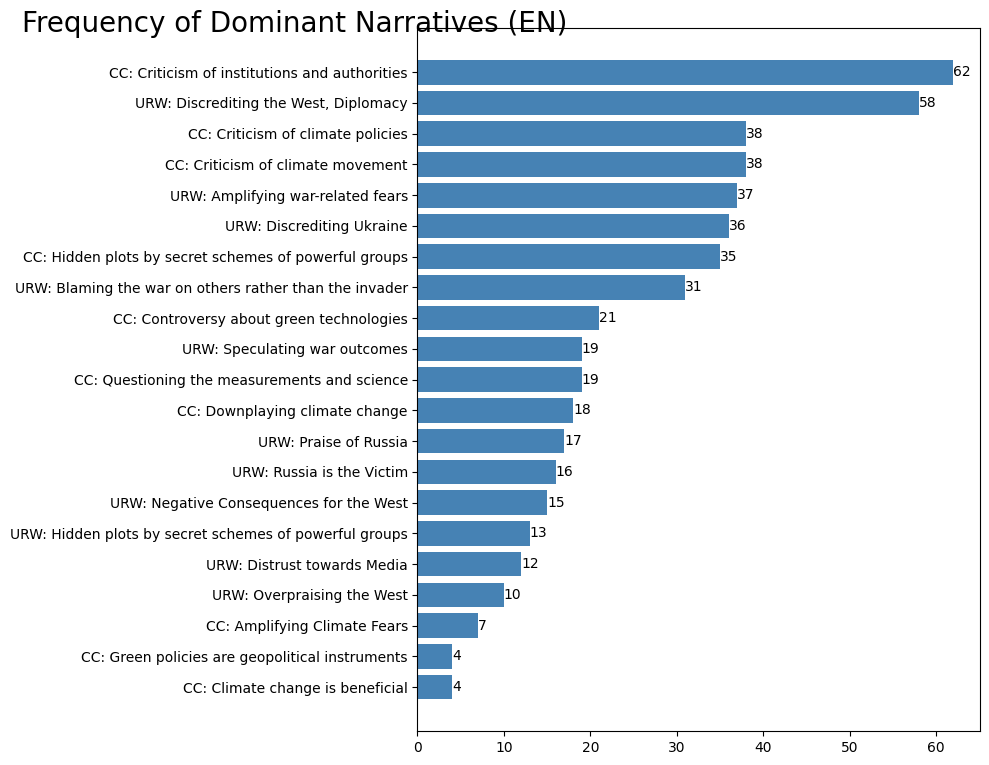

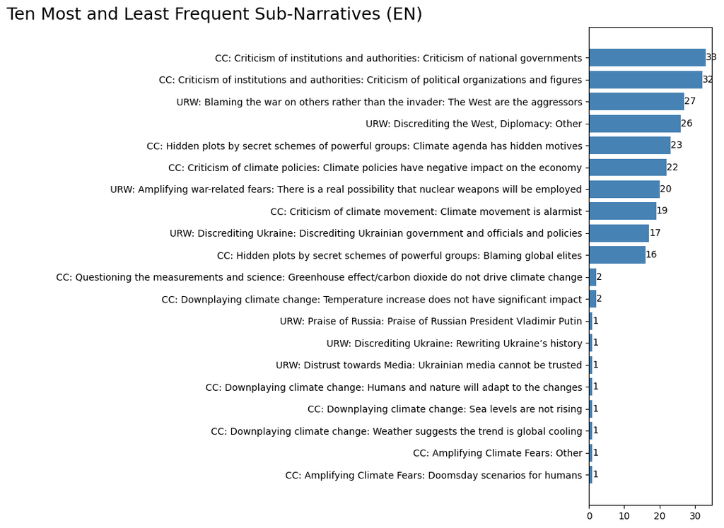

```python
# Count dominant narrative and subnarrative frequencies
dom_classes_sum = df[dom_mlb.classes_].sum().sort_values(ascending=True)
sub_classes_sum = df[sub_mlb.classes_].sum().sort_values(ascending=True)

plt.figure(figsize=(10, 8))
plot = plt.barh(dom_classes_sum.index, dom_classes_sum.values, color='steelblue')
plt.bar_label(plot)
plt.suptitle('Frequency of Dominant Narratives (EN)', fontsize=20, x=0.3, y=0.95)
plt.tight_layout()
plt.show()

# Select most and least frequent subnarratives
most_and_least_freq_subs = pd.concat([sub_classes_sum.head(10), sub_classes_sum.tail(10)])
plt.figure(figsize=(10, 8))
plt.suptitle('Ten Most and Least Frequent Sub-Narratives (EN)', fontsize=18, x=0.25, y=0.97)
plot = plt.barh(most_and_least_freq_subs.index, most_and_least_freq_subs.values, color='steelblue')
plt.bar_label(plot)
plt.tight_layout()
plt.show()
```

This is a Class distribution summary

```python
print('Number of sub-classes:      ', len(sub_mlb.classes_))
print('Number of sub URW classes:  ', len(sub_URW_classes))
print('Number of sub CC classes:   ', len(sub_CC_classes))
print()
print('Number of dominant classes: ', len(dom_mlb.classes_))
print('Number of dom URW classes:  ', len(dom_URW_classes))
print('Number of dom CC classes:   ', len(dom_CC_classes))
print("The missing class in these counts is the 'Other' class.")
```

```
Number of sub-classes:       83
Number of sub URW classes:   42
Number of sub CC classes:    41

Number of dominant classes:  21
Number of dom URW classes:   11
Number of dom CC classes:    10
The missing class in these counts is the 'Other' class.
```

**Topic distribution** (EN only): This code groups both dominant and sub-narrative labels into two main thematic domains—Climate Change (CC) and Ukraine-Russia War (URW) by checking label prefixes.

It then computes the distribution of these topics across the dataset and visualizes the result using a bar chart with counts displayed on top of each bar.

```
topic
Other    169
URW      127
CC       103
Name: count, dtype: int64
```

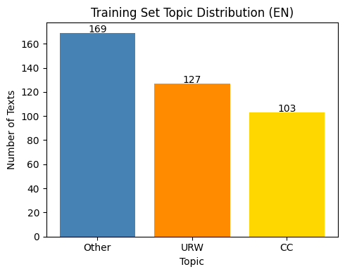

```python
# these work correctly since labels literally start with 'CC:' and 'URW:'
dom_URW_classes = [cl for cl in dom_mlb.classes_ if cl.startswith('URW')]
dom_CC_classes  = [cl for cl in dom_mlb.classes_ if cl.startswith('CC')]
sub_URW_classes = [cls for cls in sub_mlb.classes_ if cls.startswith('URW')]
sub_CC_classes  = [cls for cls in sub_mlb.classes_ if cls.startswith('CC')]

def derive_topics(row):
    if row[dom_CC_classes].sum() >= 1:
        return 'CC'
    if row[dom_URW_classes].sum() >= 1:
        return 'URW'
    return 'Other'

df['topic'] = df.apply(derive_topics, axis=1)

count = df['topic'].value_counts()
print(count)

fig, ax = plt.subplots(figsize=(5, 4))
ax.bar(count.index, count.values,
       color=['steelblue', 'darkorange', 'gold'][:len(count)])
for i, (lbl, val) in enumerate(zip(count.index, count.values)):
    ax.text(i, val + 0.5, str(val), ha='center')
ax.set_xlabel('Topic')
ax.set_ylabel('Number of Texts')
ax.set_title('Training Set Topic Distribution (EN)')
plt.tight_layout()
plt.show()
```

** Correlation matrices**: we compute and visualize pairwise correlations between dominant narrative labels to understand how often different labels co-occur in the same articles.

First, we build a correlation matrix over all dominant labels using .corr(), which measures how strongly each pair of binary label columns is related. To highlight only meaningful relationships, it filters and annotates only correlation values above 0.4, making the heatmap easier to interpret.

The same analysis is then repeated separately for the two main thematic groups—URW (Ukraine-Russia War) and CC (Climate Change) by restricting the correlation computation to labels belonging to each domain.

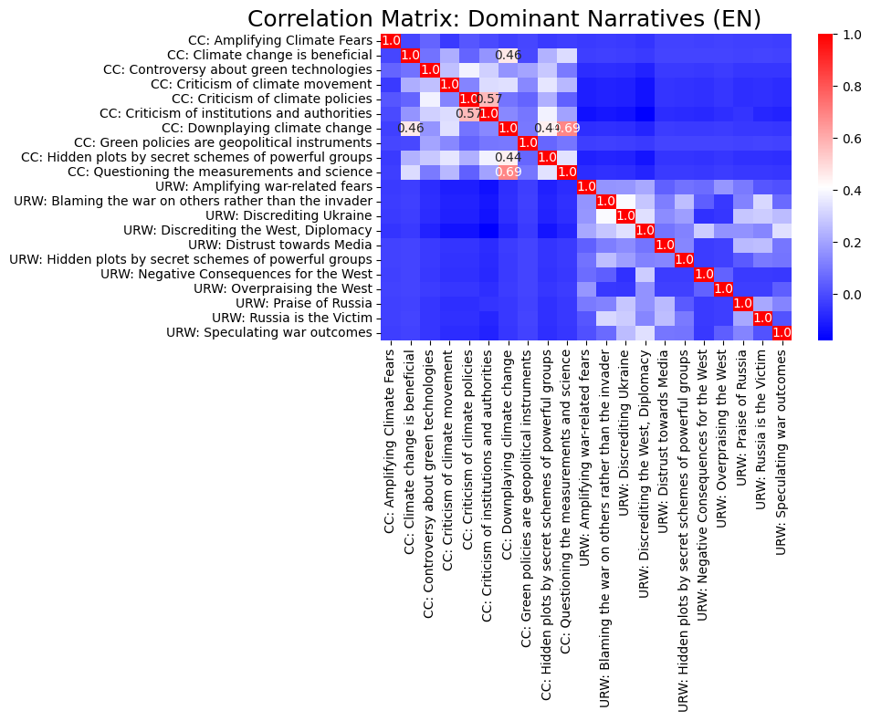

```python
# All dominant classes
dom_matrix = df[dom_mlb.classes_].corr()
important_corr = np.where(dom_matrix > 0.4, np.round(dom_matrix, 2), '')
plt.figure(figsize=(10, 8))
heatmap = sns.heatmap(dom_matrix, cmap='bwr', annot=important_corr, fmt='')
heatmap.set_title('Correlation Matrix: Dominant Narratives (EN)', fontsize=18, x=0.3)
plt.tight_layout()
plt.show()
```

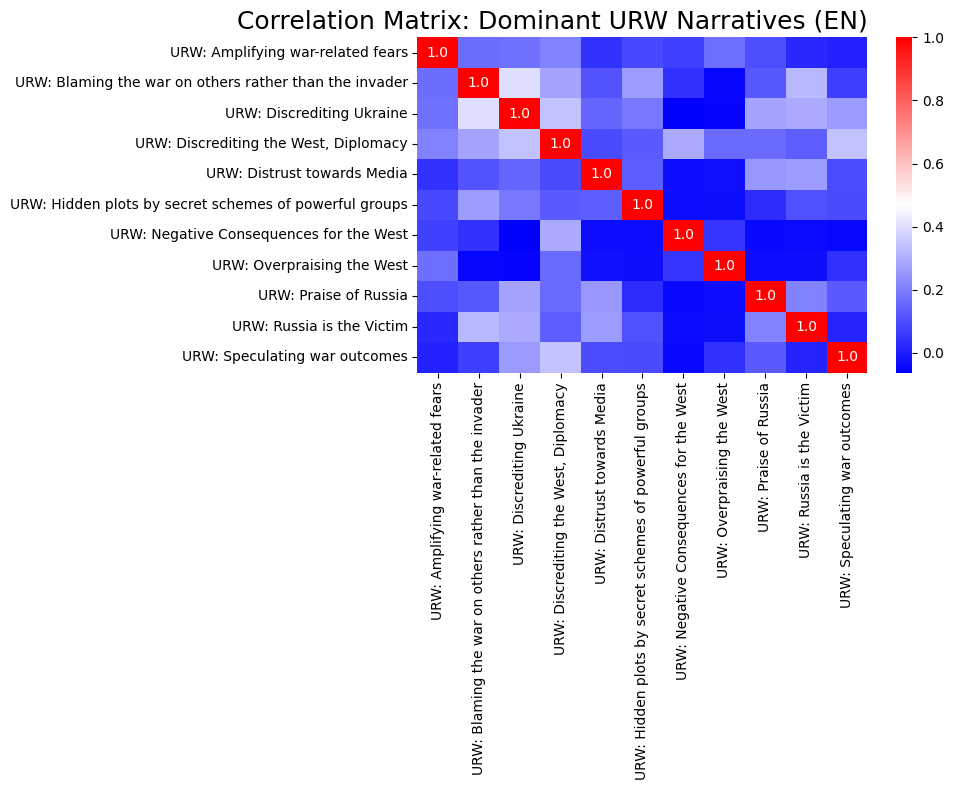

```python
# URW dominant classes
dom_URW_matrix = df[dom_URW_classes].corr()
important_corr = np.where(dom_URW_matrix > 0.4, np.round(dom_URW_matrix, 2), '')
plt.figure(figsize=(10, 8))
heatmap = sns.heatmap(dom_URW_matrix, cmap='bwr', annot=important_corr, fmt='')
heatmap.set_title('Correlation Matrix: Dominant URW Narratives (EN)', fontsize=18, x=0.3)
plt.tight_layout()
plt.show()
```

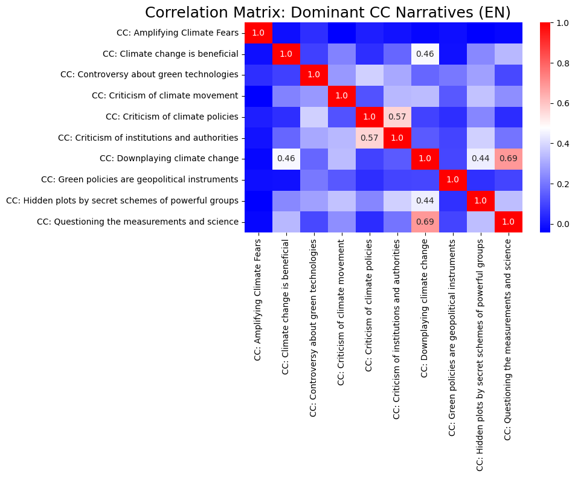

```python
# CC dominant classes
dom_CC_matrix = df[dom_CC_classes].corr()
important_corr = np.where(dom_CC_matrix > 0.4, np.round(dom_CC_matrix, 2), '')
plt.figure(figsize=(10, 8))
heatmap = sns.heatmap(dom_CC_matrix, cmap='bwr', annot=important_corr, fmt='')
heatmap.set_title('Correlation Matrix: Dominant CC Narratives (EN)', fontsize=18, x=0.3)
plt.tight_layout()
plt.show()
```

Thie following code identifies the strongest co-occurrences between sub-narrative labels within each domain (CC and URW) by analyzing their correlation structure.

First, it computes the pairwise correlation matrix among sub-narrative binary columns, then reshapes it into a long format using .unstack(), producing all label-pair combinations. The pairs are sorted in descending order to highlight the strongest positive correlations, duplicate entries are removed, and the top 10 most strongly correlated sub-narrative pairs are extracted.

The same process is repeated separately for Climate Change (CC) and Ukraine-Russia War (URW) sub-narratives, allowing to compare which fine-grained narratives tend to co-occur most frequently within each thematic domain.

```python
# Top correlated sub-narrative pairs (CC)
sub_CC_corr = (df[sub_CC_classes].corr()
               .unstack()
               .sort_values(ascending=False)
               .drop_duplicates()
               .head(10))
display(pd.DataFrame(sub_CC_corr, columns=['correlation']))

# Top correlated sub-narrative pairs (URW)
sub_URW_corr = (df[sub_URW_classes].corr()
                .unstack()
                .sort_values(ascending=False)
                .drop_duplicates()
                .head(10))
display(pd.DataFrame(sub_URW_corr, columns=['correlation']))
```

|  |  | correlation |
| --- | --- | --- |
| CC: Questioning the measurements and science: Scientific community is unreliable | CC: Questioning the measurements and science: Scientific community is unreliable | 1.000000 |
| CC: Controversy about green technologies: Renewable energy is costly | CC: Controversy about green technologies: Renewable energy is unreliable | 0.731506 |
| CC: Green policies are geopolitical instruments: Climate-related international relations are abusive/exploitative | CC: Downplaying climate change: Humans and nature will adapt to the changes | 0.706218 |
| CC: Downplaying climate change: Weather suggests the trend is global cooling | CC: Downplaying climate change: Temperature increase does not have significant impact | 0.706218 |
| CC: Downplaying climate change: Human activities do not impact climate change | CC: Questioning the measurements and science: Data shows no temperature increase | 0.705323 |
| CC: Climate change is beneficial: Temperature increase is beneficial | CC: Downplaying climate change: Climate cycles are natural | 0.630061 |
| CC: Criticism of climate movement: Climate movement is corrupt | CC: Criticism of climate movement: Ad hominem attacks on key activists | 0.517568 |
| CC: Downplaying climate change: CO2 concentrations are too small to have an impact | CC: Climate change is beneficial: CO2 is beneficial | 0.511824 |
| CC: Questioning the measurements and science: Methodologies/metrics used are unreliable/faulty | CC: Downplaying climate change: Human activities do not impact climate change | 0.493004 |
| CC: Downplaying climate change: CO2 concentrations are too small to have an impact | CC: Questioning the measurements and science: Scientific community is unreliable | 0.486941 |

|  |  | correlation |
| --- | --- | --- |
| URW: Speculating war outcomes: Ukrainian army is collapsing | URW: Speculating war outcomes: Ukrainian army is collapsing | 1.000000 |
| URW: Discrediting Ukraine: Situation in Ukraine is hopeless | URW: Speculating war outcomes: Ukrainian army is collapsing | 0.626820 |
| URW: Negative Consequences for the West: The conflict will increase the Ukrainian refugee flows to Europe | URW: Discrediting the West, Diplomacy: The EU is divided | 0.574434 |
| URW: Amplifying war-related fears: Russia will also attack other countries | URW: Amplifying war-related fears: There is a real possibility that nuclear weapons will be employed | 0.564799 |
| URW: Discrediting the West, Diplomacy: West is tired of Ukraine | URW: Discrediting Ukraine: Situation in Ukraine is hopeless | 0.531444 |
|  | URW: Speculating war outcomes: Ukrainian army is collapsing | 0.521921 |
| URW: Praise of Russia: Russia has international support from a number of countries and people | URW: Praise of Russia: Other | 0.497481 |
|  | URW: Russia is the Victim: The West is russophobic | 0.496207 |
| URW: Discrediting Ukraine: Ukraine is associated with nazism | URW: Russia is the Victim: UA is anti-RU extremists | 0.466087 |
| URW: Blaming the war on others rather than the invader: Ukraine is the aggressor | URW: Russia is the Victim: UA is anti-RU extremists | 0.466087 |

** Text length analysis**: We compute statistics related to text length

```
count     399.000000
mean     2984.250627
std       858.101505
min       543.000000
25%      2326.000000
50%      2960.000000
75%      3597.000000
max      5603.000000
Name: text_length, dtype: float64
```

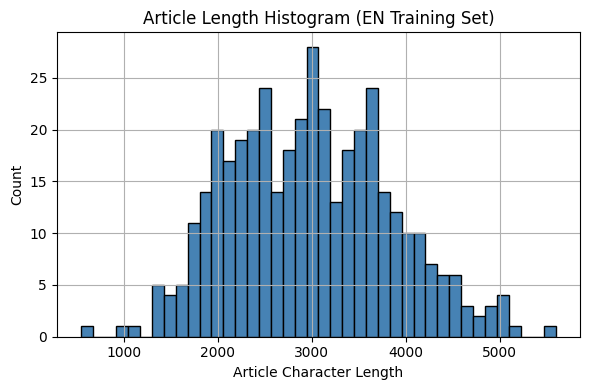

```python
df['text_length'] = df['text'].str.len()

print(df['text_length'].describe())


plt.figure(figsize=(6, 4))
df['text_length'].hist(bins=40, color='steelblue', edgecolor='black')
plt.xlabel('Article Character Length')
plt.ylabel('Count')
plt.title('Article Length Histogram (EN Training Set)')
plt.tight_layout()
plt.show()
```

> **NLP Case Study - Subtask_2 | Manuel Carlucci | Mtr: 855237 | m.carlucci69@studenti.uniba.it**